# Group107_Yeast

## Machine Learning Assignment for Yeast Classification

## Group ID: ML Group 107

1. SUTAR MOHASIN APPASO, BITS ID: **2022AC05381**
2. PARAB ADESH ASHOK ARATI, BITS ID: **2022AC05392**
3. JEET ARORA, BITS ID: **2022AC05760**

```python
#importing required libraries
import numpy as np
import pandas as pd
import matplotlib.pyplot as plt
import seaborn as sns
from sklearn.preprocessing import *
from sklearn.model_selection import train_test_split, GridSearchCV
from sklearn.linear_model import LogisticRegression
from sklearn.model_selection import KFold
from sklearn.model_selection import StratifiedKFold
from sklearn.preprocessing import StandardScaler
from sklearn.metrics import accuracy_score, log_loss, f1_score, roc_auc_score, mean_absolute_error, precision_score, recall_score
from sklearn.metrics import precision_recall_fscore_support
from sklearn.model_selection import cross_validate
from sklearn.model_selection import cross_val_score
from sklearn.model_selection import learning_curve, validation_curve
from sklearn.linear_model import LogisticRegression
from sklearn.pipeline import make_pipeline
from imblearn.over_sampling import SMOTE
```

```python
#importing the dataset
df = pd.read_csv("yeast1.csv")
```

### Data Preproccessing and Cleaning

Here we perform the EDA on the dataset.

Data contains 8 Features and plotted the outliers using box plot.

df['name'].value_counts() shows that ERL class is present in only 5 rows, This shows that in the target variable, there is a class imbalance

```python
df.head()
```

|  | mcg | gvh | alm | mit | erl | pox | vac | nuc | name |
| --- | --- | --- | --- | --- | --- | --- | --- | --- | --- |
| 0 | 0.58 | 0.61 | 0.47 | 0.13 | 0.5 | 0.0 | 0.48 | 0.22 | MIT |
| 1 | 0.43 | 0.67 | 0.48 | 0.27 | 0.5 | 0.0 | 0.53 | 0.22 | MIT |
| 2 | 0.64 | 0.62 | 0.49 | 0.15 | 0.5 | 0.0 | 0.53 | 0.22 | MIT |
| 3 | 0.58 | 0.44 | 0.57 | 0.13 | 0.5 | 0.0 | 0.54 | 0.22 | NUC |
| 4 | 0.42 | 0.44 | 0.48 | 0.54 | 0.5 | 0.0 | 0.48 | 0.22 | MIT |

```python
df.tail()
```

|  | mcg | gvh | alm | mit | erl | pox | vac | nuc | name |
| --- | --- | --- | --- | --- | --- | --- | --- | --- | --- |
| 1479 | 0.81 | 0.62 | 0.43 | 0.17 | 0.5 | 0.0 | 0.53 | 0.22 | ME2 |
| 1480 | 0.47 | 0.43 | 0.61 | 0.40 | 0.5 | 0.0 | 0.48 | 0.47 | NUC |
| 1481 | 0.67 | 0.57 | 0.36 | 0.19 | 0.5 | 0.0 | 0.56 | 0.22 | ME2 |
| 1482 | 0.43 | 0.40 | 0.60 | 0.16 | 0.5 | 0.0 | 0.53 | 0.39 | NUC |
| 1483 | 0.65 | 0.54 | 0.54 | 0.13 | 0.5 | 0.0 | 0.53 | 0.22 | CYT |

df.columns

```python
df.shape
```

```
(1484, 9)
```

```python
#checking for null values in any column
df.isnull().sum()
```

```
mcg     0
gvh     0
alm     0
mit     0
erl     0
pox     0
vac     0
nuc     0
name    0
dtype: int64
```

```python
df.describe().T
```

|  | count | mean | std | min | 25% | 50% | 75% | max |
| --- | --- | --- | --- | --- | --- | --- | --- | --- |
| mcg | 1484.0 | 0.500121 | 0.137299 | 0.11 | 0.41 | 0.49 | 0.58 | 1.00 |
| gvh | 1484.0 | 0.499933 | 0.123924 | 0.13 | 0.42 | 0.49 | 0.57 | 1.00 |
| alm | 1484.0 | 0.500034 | 0.086670 | 0.21 | 0.46 | 0.51 | 0.55 | 1.00 |
| mit | 1484.0 | 0.261186 | 0.137098 | 0.00 | 0.17 | 0.22 | 0.32 | 1.00 |
| erl | 1484.0 | 0.504717 | 0.048351 | 0.50 | 0.50 | 0.50 | 0.50 | 1.00 |
| pox | 1484.0 | 0.007500 | 0.075683 | 0.00 | 0.00 | 0.00 | 0.00 | 0.83 |
| vac | 1484.0 | 0.499885 | 0.057797 | 0.00 | 0.48 | 0.51 | 0.53 | 0.73 |
| nuc | 1484.0 | 0.276199 | 0.106491 | 0.00 | 0.22 | 0.22 | 0.30 | 1.00 |

```python
df['name'].unique()
```

```
array(['MIT', 'NUC', 'CYT', 'ME1', 'EXC', 'ME2', 'ME3', 'VAC', 'POX',
       'ERL'], dtype=object)
```

```python
df['name'].value_counts()
```

```
CYT    463
NUC    429
MIT    244
ME3    163
ME2     51
ME1     44
EXC     35
VAC     30
POX     20
ERL      5
Name: name, dtype: int64
```

```
[Text(0.5, 0, 'Yeast Name'), Text(0, 0.5, 'Number of samples')]
```

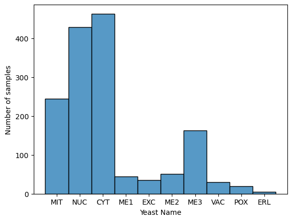

```python
histogramYeast = sns.histplot(data=df, x='name')
histogramYeast.set(xlabel="Yeast Name", ylabel="Number of samples")
```

### As the count for ERL, POX and VAC value count is less we can visualize the class imbalance

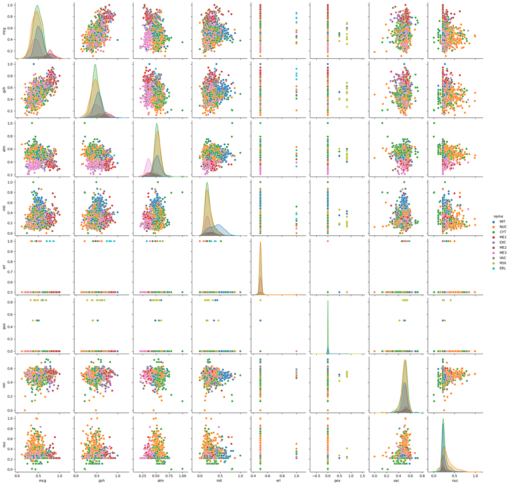

```python
sns.pairplot(df,hue = "name")
```

### As the Target variable contains the names , which is object type, We have converted the labels into numerical values using Label Encoder

```python
# Convert the "name" column into numerical labels using LabelEncoder

le = LabelEncoder()
df['name'] = le.fit_transform(df['name'])
df.head()
```

|  | mcg | gvh | alm | mit | erl | pox | vac | nuc | name |
| --- | --- | --- | --- | --- | --- | --- | --- | --- | --- |
| 0 | 0.58 | 0.61 | 0.47 | 0.13 | 0.5 | 0.0 | 0.48 | 0.22 | 6 |
| 1 | 0.43 | 0.67 | 0.48 | 0.27 | 0.5 | 0.0 | 0.53 | 0.22 | 6 |
| 2 | 0.64 | 0.62 | 0.49 | 0.15 | 0.5 | 0.0 | 0.53 | 0.22 | 6 |
| 3 | 0.58 | 0.44 | 0.57 | 0.13 | 0.5 | 0.0 | 0.54 | 0.22 | 7 |
| 4 | 0.42 | 0.44 | 0.48 | 0.54 | 0.5 | 0.0 | 0.48 | 0.22 | 6 |

```python
#df['name'].value_counts()
```

### Plotting Outliers for each Feature

Here we have printed the outliers for each features using boxplot

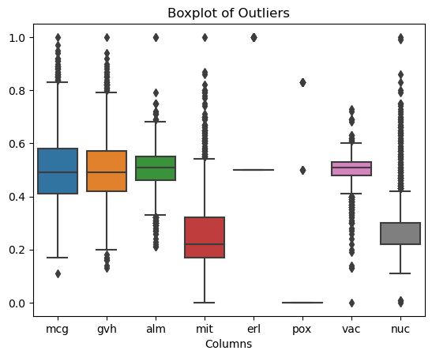

```python
# Create a boxplot using Seaborn
X = df.drop(columns = ['name'])
sns.boxplot(data=X)
# Set plot title and labels
plt.title('Boxplot of Outliers')
plt.xlabel('Columns')

# Display the plot
plt.show()
```

## Correlation matrix

Below is the Correlation matrix amongst the features. It shows that mcg and gvh features are co-related. they have correlation score of 0.58 as visible in the graph.

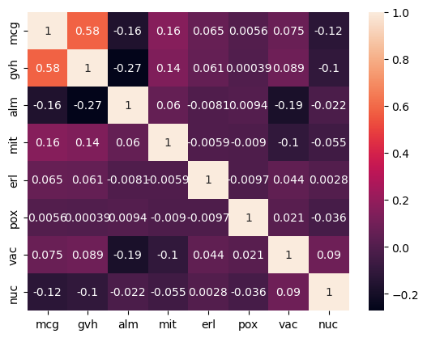

```python
correlation_matrix=X.corr()
correlation_matrix
dataplot = sns.heatmap(X.corr(),annot=True)
plt.show()
```

## Split the dataset into training and test sets

### Case 1: 80% Train 20% Test

### Case 2: 90% Train 10% Test

```python
X_train_1, X_test_1, y_train_1, y_test_1 = train_test_split(X,y,test_size = 0.2,random_state=42)
X_train_2, X_test_2, y_train_2, y_test_2 = train_test_split(X,y,test_size = 0.1,random_state=42)
print("Case1 Train: 80% Test 20%")
print(X_train1.shape,X_test_1.shape)
print(y_train1.shape,y_test_1.shape)
print("Case1 Train: 90% Test 10%")
print(X_train2.shape,X_test_2.shape)
print(y_train2.shape,y_test_2.shape)
```

```
Case1 Train: 80% Test 20%
(1187, 8) (297, 8)
(1187,) (297,)
Case1 Train: 90% Test 10%
(1335, 8) (149, 8)
(1335,) (149,)
```

```python
model = LogisticRegression(multi_class='ovr')
model.fit(X_train_1, y_train_1)
y_predict_1 = model.predict(X_test_1)
train_score_1 = model.score(X_train_1, y_train_1)
test_score_1 = model.score(X_test_1, y_test_1)
print("The train score Case-1 is {}".format(train_score_1*100))
print("The test score Case-1 is {}".format(test_score_1*100))
accuracy_1 = accuracy_score(y_test_1, y_predict_1)
print("Accuracy Case-1: {:.2f}".format(accuracy_1*100))


model = LogisticRegression(multi_class='ovr')
model.fit(X_train_2, y_train_2)
y_predict_2 = model.predict(X_test_2)
train_score_2 = model.score(X_train_2, y_train_2)
test_score_2 = model.score(X_test_2, y_test_2)
print("The train score Case-2 is {}".format(train_score_2*100))
print("The test score Case-2 is {}".format(test_score2*100))
accuracy_2 = accuracy_score(y_test_2, y_predict_2)
print("Accuracy Case-2: {:.2f}".format(accuracy_2*100))
```

```
The train score Case-1 is 54.25442291491154
The test score Case-1 is 57.23905723905723
Accuracy Case-1: 57.24
The train score Case-2 is 54.382022471910105
The test score Case-2 is 57.71812080536913
Accuracy Case-2: 57.72
```

### K Fold Cross Validation

This data is split into training and testing sets using 90 and10 split and 80 and 20

We have used StratifiedKFold with 5 splits and split the training data into k-folds using split(). Stratified k-fold cross-validation ensures that the class distribution is maintained in each fold.

In the loop, the pipeline is fitted on the training data for each fold (pipeline.fit()) and the accuracy score is computed on the corresponding test data (pipeline.score()). The accuracy scores for each fold are stored in the scores list.

### K Fold Validation with Case 1

```python
#K Fold Validation with Case 1
X_train, X_test, y_train, y_test = train_test_split(X,y,test_size = 0.2)

pipeline = make_pipeline(LogisticRegression(multi_class='ovr'))
strtfdKFold = StratifiedKFold(n_splits=5)
kfold = strtfdKFold.split(X_train, y_train)
scores = []
for k, (train, test) in enumerate(kfold):
    pipeline.fit(X_train.iloc[train, :], y_train.iloc[train])
    score = pipeline.score(X_train.iloc[test, :], y_train.iloc[test])
    scores.append(score)
    print('Fold: %2d, Training/Test Split Distribution: %s, Accuracy: %.3f' % (k+1, np.bincount(y_train.iloc[train]), score))
    print('\nCross-Validation accuracy: %.3f +/- %.3f \n' %(np.mean(scores), np.std(scores)))
```

```
Fold:  1, Training/Test Split Distribution: [304   3  25  28  31 104 151 271  13  19], Accuracy: 0.525

Cross-Validation accuracy: 0.525 +/- 0.000
```

```
Fold:  2, Training/Test Split Distribution: [304   3  25  28  31 104 150 272  13  19], Accuracy: 0.529

Cross-Validation accuracy: 0.527 +/- 0.002

Fold:  3, Training/Test Split Distribution: [304   4  26  28  31 104 150 271  13  19], Accuracy: 0.527

Cross-Validation accuracy: 0.527 +/- 0.002

Fold:  4, Training/Test Split Distribution: [304   3  26  28  32 104 150 271  13  19], Accuracy: 0.536

Cross-Validation accuracy: 0.529 +/- 0.004

Fold:  5, Training/Test Split Distribution: [304   3  26  28  31 104 151 271  12  20], Accuracy: 0.515

Cross-Validation accuracy: 0.527 +/- 0.007
```

### K Fold Validation with Case 2

```python
#K Fold Validation with Case 2
X_train, X_test, y_train, y_test = train_test_split(X,y,test_size = 0.1)

pipeline = make_pipeline(LogisticRegression(multi_class='ovr'))
strtfdKFold = StratifiedKFold(n_splits=5)
kfold = strtfdKFold.split(X_train, y_train)
scores = []
for k, (train, test) in enumerate(kfold):
    pipeline.fit(X_train.iloc[train, :], y_train.iloc[train])
    score = pipeline.score(X_train.iloc[test, :], y_train.iloc[test])
    scores.append(score)
    print('Fold: %2d, Training/Test Split Distribution: %s, Accuracy: %.3f' % (k+1, np.bincount(y_train.iloc[train]), score))
    print('\nCross-Validation accuracy: %.3f +/- %.3f \n' %(np.mean(scores), np.std(scores)))
```

```
Fold:  1, Training/Test Split Distribution: [331   4  24  29  35 120 177 312  16  20], Accuracy: 0.506

Cross-Validation accuracy: 0.506 +/- 0.000

Fold:  2, Training/Test Split Distribution: [331   4  25  28  35 120 178 312  15  20], Accuracy: 0.547

Cross-Validation accuracy: 0.526 +/- 0.021

Fold:  3, Training/Test Split Distribution: [331   4  25  29  34 120 178 312  15  20], Accuracy: 0.554

Cross-Validation accuracy: 0.536 +/- 0.021

Fold:  4, Training/Test Split Distribution: [331   4  25  29  34 120 178 312  15  20], Accuracy: 0.573

Cross-Validation accuracy: 0.545 +/- 0.025

Fold:  5, Training/Test Split Distribution: [332   4  25  29  34 120 177 312  15  20], Accuracy: 0.543

Cross-Validation accuracy: 0.545 +/- 0.022
```

## Model Building with Regularization

We have split the data into training and testing sets using train_test_split().

**Then, we create a logistic regression model with L2 regularization (Ridge) by setting penalty='l2' in the LogisticRegression The C parameter is set to 10.0, which controls the inverse of the regularization strength.**

After fitting the model to the training data using fit(), we have calculated the accuracy score.

```python
X_train, X_test, y_train, y_test = train_test_split(X, y, test_size=0.2, random_state=42)

model = LogisticRegression(multi_class='ovr')
model.fit(X_train, y_train)
y_predict = model.predict(X_test)
accuracy = accuracy_score(y_test, y_predict)
print("Accuracy score without regularization:", accuracy*100)
train_score = model.score(X_train, y_train)
test_score = model.score(X_test, y_predict)
print("The train score is {}".format(train_score_2*100))
print("The test score is {}".format(test_score2*100))

# Apply logistic regression with L2 regularization
model = LogisticRegression(multi_class='ovr',penalty='l2', C=10.0)
model.fit(X_train, y_train)

# Make predictions on the test set
y_predict = model.predict(X_test)
# Calculate and print the accuracy score
accuracy = accuracy_score(y_test, y_predict)
print("Accuracy score with regularization:", accuracy*100)
train_score = model.score(X_train, y_train)
test_score = model.score(X_test, y_predict)
print("The train score is {}".format(train_score_2*100))
print("The test score is {}".format(test_score2*100))
```

```
Accuracy score without regularization: 57.23905723905723
The train score is 54.382022471910105
The test score is 57.71812080536913
Accuracy score with regularization: 61.95286195286195
The train score is 54.382022471910105
The test score is 57.71812080536913
```

### We can comment that after Regularization the accurracy score is increased

### Calculate all the evaluation metrics and choose best for your model

```python
X_train_1, X_test_1, y_train_1, y_test_1 = train_test_split(X, y, test_size=0.1)
X_train_2, X_test_2, y_train_2, y_test_2 = train_test_split(X, y, test_size=0.2)

# Create and fit the logistic regression models
model_1 = LogisticRegression(multi_class='ovr')
model_1.fit(X_train_1, y_train_1)

model_2 = LogisticRegression(multi_class='ovr')
model_2.fit(X_train_2, y_train_2)

# Make predictions on the test sets
y_pred_1 = model_1.predict(X_test_1)
y_pred_2 = model_2.predict(X_test_2)

# Calculate evaluation metrics for the 90:10 split
accuracy_1 = accuracy_score(y_test_1, y_pred_1)
precision_1 = precision_score(y_test_1, y_pred_1,average='micro')
recall_1 = recall_score(y_test_1, y_pred_1,average='micro')
f1_1 = f1_score(y_test_1, y_pred_1,average='micro')


# Calculate evaluation metrics for the 80:20 split
accuracy_2 = accuracy_score(y_test_2, y_pred_2)
precision_2 = precision_score(y_test_2, y_pred_2,average='micro')
recall_2 = recall_score(y_test_2, y_pred_2,average='micro')
f1_2 = f1_score(y_test_2, y_pred_2,average='micro')


# Print the evaluation metrics for the 90:10 split
print("90:10 Split Evaluation Metrics:")
print("Accuracy:", accuracy_1)
print("Precision:", precision_1)
print("Recall:", recall_1)
print("F1 Score:", f1_1)
print()

# Print the evaluation metrics for the 80:20 split
print("80:20 Split Evaluation Metrics:")
print("Accuracy:", accuracy_2)
print("Precision:", precision_2)
print("Recall:", recall_2)
print("F1 Score:", f1_2)
```

```
90:10 Split Evaluation Metrics:
Accuracy: 0.5973154362416108
Precision: 0.5973154362416108
Recall: 0.5973154362416108
F1 Score: 0.5973154362416108

80:20 Split Evaluation Metrics:
Accuracy: 0.5387205387205387
Precision: 0.5387205387205387
Recall: 0.5387205387205387
F1 Score: 0.5387205387205387
```

### By Comparing the accuracy Score of Case 1 and Case 2 , we can say that Training and Test Split of 90%,10% is giving better accuracy. As there is class imbalance in data the training data is more in Case of 90% 10% split, so model is better trained.

### Comment on under fitting/overfitting/just right mode

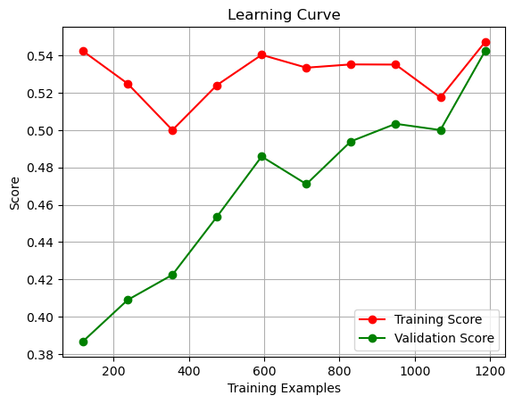

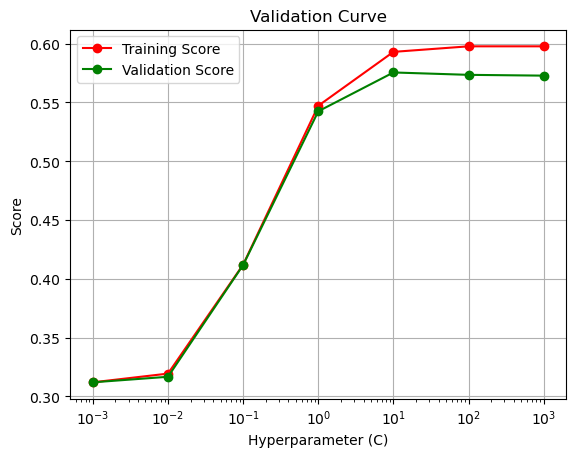

```python
model = LogisticRegression(multi_class='ovr')

# Plot the learning curve
train_sizes, train_scores, val_scores = learning_curve(model, X, y, train_sizes=np.linspace(0.1, 1.0, 10), cv=5)
train_scores_mean = np.mean(train_scores, axis=1)
val_scores_mean = np.mean(val_scores, axis=1)

plt.figure()
plt.title("Learning Curve")
plt.xlabel("Training Examples")
plt.ylabel("Score")
plt.grid()
plt.plot(train_sizes, train_scores_mean, 'o-', color="r", label="Training Score")
plt.plot(train_sizes, val_scores_mean, 'o-', color="g", label="Validation Score")
plt.legend(loc="best")
plt.show()

# Plot the validation curve
param_range = np.logspace(-3, 3, 7)
train_scores, val_scores = validation_curve(model, X, y, param_name="C", param_range=param_range, cv=5)
train_scores_mean = np.mean(train_scores, axis=1)
val_scores_mean = np.mean(val_scores, axis=1)

plt.figure()
plt.title("Validation Curve")
plt.xlabel("Hyperparameter (C)")
plt.ylabel("Score")
plt.grid()
plt.plot(param_range, train_scores_mean, 'o-', color="r", label="Training Score")
plt.plot(param_range, val_scores_mean, 'o-', color="g", label="Validation Score")
plt.legend(loc="best")
plt.xscale('log')
plt.show()
```